# Linear modeling

This document breaks down the linear modeling to assess factors that seem to be important.

setup:

```r
source("utils.R")
raw_dataset <- get_raw_dataset()
```

```
## ✔ Reading from "gender relationships hairstyle de-auth".
```

```
## ✔ Range 'A:AO'.
```

```
## • `To the best of your knowledge, which gender identity below does your partner
##   most identify with?` -> `To the best of your knowledge, which gender identity
##   below does your partner most identify with?...4`
## • `To the best of your knowledge, which gender identity below does your partner
##   most identify with?` -> `To the best of your knowledge, which gender identity
##   below does your partner most identify with?...24`
```

[output not shown]

[output cut: 71 more lines]

```
##  [3] "Non binary"
##  [4] "Nonbinary"
##  [5] "non binary"
##  [6] "nonbinary"
##  [7] "Non-binary"
##  [8] "NB"
##  [9] "Nb"
## [10] "Genderqueer"
## [11] "Genderfluid"
## [12] "Gender fluid"
## [13] "Bigender, Bio F"
## [14] "Non-binary (AFAB and primarily feminine)"
## [15] "AFAB, but NonBinary."
## [16] "Nonbinary cis female"
## [1] "Not"     "none"    "Agender" "agender"
```

```r
source("utils.R")

data_per_participant <- create_participant_data(raw_dataset)
```

```
## [1] "Straight/heterosexual"
## [1] "Lesbian"
## [1] "Gay"
## [1] "Bisexual"   "Pansexual"  "Polysexual"
## [1] "Asexual"            "Aromantic"          "Asexual Biromantic"
## [1] "Straight/heterosexual"
## [1] "Lesbian"
## [1] "Gay"
## [1] "Bisexual"
## [1] "Pansexual"
## [1] "Asexual"            "Aromantic"          "Asexual Biromantic"
## [1] "median age: 29"
```

```r
straight_couple_data<-create_straight_couple_data(data_per_participant)
```

# Descriptive stats

Graphs of stats taht we might wanna know for modeling below

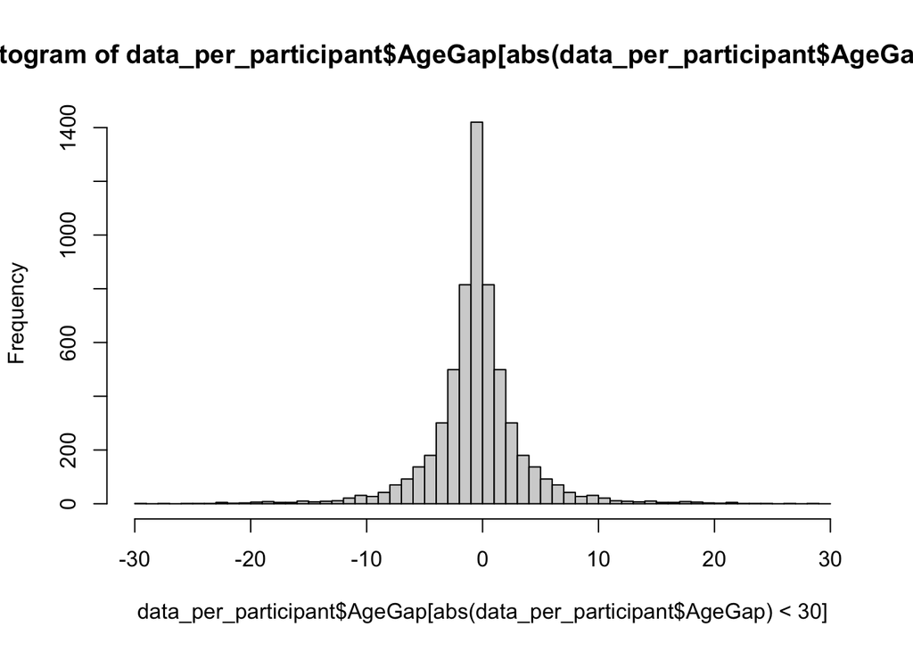

```r
hist(data_per_participant$AgeGap[abs(data_per_participant$AgeGap)<30],breaks = -30:30)
```

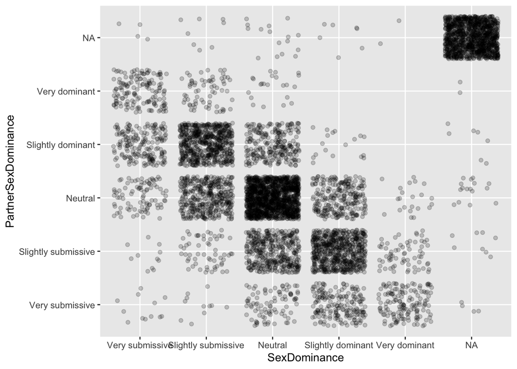

```r
library(ggplot2)

ggplot(data_per_participant,aes(SexDominance,PartnerSexDominance))+geom_jitter(alpha=0.2)
```

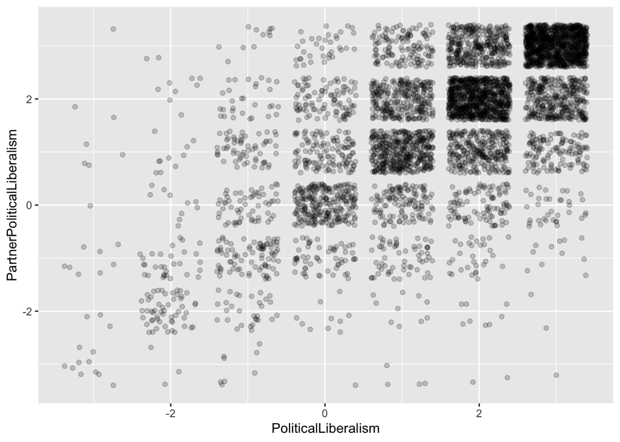

```r
ggplot(data_per_participant,aes(PoliticalLiberalism,PartnerPoliticalLiberalism))+geom_jitter(alpha=0.2)
```

```r
table(data_per_participant$MostHairRemoved12Months,data_per_participant$PartnerMostHairRemoved12Months)
```

```
##
##                        1. Natural 2. Trimmed 3. Partially removed
##   1. Natural                   42         24                   10
##   2. Trimmed                   24        134                   30
##   3. Partially removed         10         30                   50
##   4. Fully removed             26        105                   56
##
##                        4. Fully removed
##   1. Natural                         26
##   2. Trimmed                        105
##   3. Partially removed               56
##   4. Fully removed                  288
```

```r
library(dplyr)
data_per_participant_genpref<-data_per_participant %>% filter(!is.na(PubicHairGeneralPreference))
data.frame(table(data_per_participant_genpref$PubicHairGeneralPreference,data_per_participant_genpref$Gender3C)/
  rep(table(data_per_participant_genpref$Gender3C),each=5))
```

| Var1 | Var2 | Freq |
| --- | --- | --- |
| 1. Natural | Female | 0.10070671 |
| 2. Trimmed | Female | 0.37455830 |
| 3. Partially removed | Female | 0.06890459 |
| 4. Fully removed | Female | 0.14134276 |
| Don't care | Female | 0.31448763 |
| 1. Natural | Male | 0.08873239 |
| 2. Trimmed | Male | 0.20845070 |
| 3. Partially removed | Male | 0.14929577 |
| 4. Fully removed | Male | 0.36478873 |
| Don't care | Male | 0.18873239 |

[output cut: 5 more lines]

```r
primary_respondent <- data_per_participant %>% filter(SurveyRole=="PrimaryRespondent")
table(primary_respondent$`How did you find out about this survey?`)/sum(table(primary_respondent$`How did you find out about this survey?`))
```

```
##
##          r/DataIsBeautiful The pubic hair infographic
##               0.4693815064               0.3181261482
##               r/SampleSize                      Other
##               0.1690140845               0.0269442743
##          r/RedditAfterDark                    r/Polls
##               0.0107164727               0.0048989590
##             r/Infographics
##               0.0009185548
```

```r
surveysource<-table(primary_respondent$`How did you find out about this survey?`)

table(primary_respondent$`How did you find out about this survey?`,primary_respondent$Gender3C)/matrix(surveysource,nrow=length(surveysource),ncol=3)
```

```
##
##                                  Female       Male Non-binary
##   r/DataIsBeautiful          0.20482714 0.72928898 0.06262231
##   The pubic hair infographic 0.18864293 0.72954764 0.07603465
##   r/SampleSize               0.52717391 0.41304348 0.04891304
##   Other                      0.30681818 0.50000000 0.17045455
##   r/RedditAfterDark          0.25714286 0.71428571 0.02857143
##   r/Polls                    0.31250000 0.62500000 0.00000000
##   r/Infographics             0.00000000 1.00000000 0.00000000
```

# Basic LM

This one is a very basic model using almost all the data we have available to us. Uses all items for which we have more than 5400 individual entries (doubling up because each submission included two individuals).

Also keeps interactions between them I found to be significant, and I also list non-significant (p>0.1) interactions I’ve tried. Did not keep gender interactions with NB or Signle relationships because the group is too small, only around 300 responses.

Also includes some derived values I have tried. Again, I’ve listed the derived values found and not-significant

```r
table(data_per_participant$`How do you currently keep your pubic hair?`)/sum(table(data_per_participant$`How do you currently keep your pubic hair?`))
```

```
##
##           1. Natural           2. Trimmed 3. Partially removed
##            0.2295966            0.4171543            0.1117955
##     4. Fully removed
##            0.2414536
```

```r
model_basic<-lm(
  as.numeric(`How do you currently keep your pubic hair?`)~Gender3C*AgeC + RTypeLivingTogetherVs+OutsideUSA+SurveyRole*Gender3C+`How did you find out about this survey?`
  ,
  data_per_participant
  )
summary(model_basic)
```

```
##
## Call:
## lm(formula = as.numeric(`How do you currently keep your pubic hair?`) ~
##     Gender3C * AgeC + RTypeLivingTogetherVs + OutsideUSA + SurveyRole *
##         Gender3C + `How did you find out about this survey?`,
##     data = data_per_participant)
##
## Residuals:
##     Min      1Q  Median      3Q     Max
## -2.2310 -0.7695 -0.1840  0.9185  2.2574
##
## Coefficients:
##                                                                      Estimate
## (Intercept)                                                          2.529163
## Gender3CMale                                                        -0.320243
## Gender3CNon-binary                                                  -0.242845
## AgeC                                                                -0.007575
## RTypeLivingTogetherVsMarried                                        -0.061565
## RTypeLivingTogetherVsCommitted relationship                          0.098134
## RTypeLivingTogetherVsDating                                          0.134470
## RTypeLivingTogetherVsCasual                                          0.237533
## RTypeLivingTogetherVsSingle                                         -0.019667
## OutsideUSATRUE                                                       0.052502
## SurveyRoleRespondentPartner                                          0.133525
## `How did you find out about this survey?`The pubic hair infographic -0.064245
## `How did you find out about this survey?`r/SampleSize                0.073449
## `How did you find out about this survey?`Other                       0.262630
## `How did you find out about this survey?`r/RedditAfterDark           0.361893
## `How did you find out about this survey?`r/Polls                    -0.351070
## `How did you find out about this survey?`r/Infographics             -1.018513
## Gender3CMale:AgeC                                                    0.011652
## Gender3CNon-binary:AgeC                                              0.014541
## Gender3CMale:SurveyRoleRespondentPartner                            -0.470006
## Gender3CNon-binary:SurveyRoleRespondentPartner                      -0.412775
##                                                                     Std. Error
## (Intercept)                                                           0.048145
## Gender3CMale                                                          0.046181
## Gender3CNon-binary                                                    0.086244
## AgeC                                                                  0.002743
## RTypeLivingTogetherVsMarried                                          0.036738
```

[output cut: 74 more lines]

```
## `How did you find out about this survey?`Other                      **
## `How did you find out about this survey?`r/RedditAfterDark          *
## `How did you find out about this survey?`r/Polls
## `How did you find out about this survey?`r/Infographics             *
## Gender3CMale:AgeC                                                   ***
## Gender3CNon-binary:AgeC
## Gender3CMale:SurveyRoleRespondentPartner                            ***
## Gender3CNon-binary:SurveyRoleRespondentPartner                      ***
## ---
## Signif. codes:  0 '***' 0.001 '**' 0.01 '*' 0.05 '.' 0.1 ' ' 1
##
## Residual standard error: 1.041 on 5962 degrees of freedom
##   (605 observations deleted due to missingness)
## Multiple R-squared:  0.07625,    Adjusted R-squared:  0.07315
## F-statistic: 24.61 on 20 and 5962 DF,  p-value: < 2.2e-16
```

Interactions which do not seem significant which we’ve tried:

- Age*IsInUSA
- Gender3C*`How did you find out about this survey?`
- Gender*Relationship type
- Relationship type * Age
- IsUSA * Gender
- AgeGap
- `Relationship type`*IsInUSA
- I(AgeC^2)

# Slightly more expansive data

Also repeated sensible interactions from previous round, and tried out our own from this round.

```r
table(data_per_participant$Politics)
```

```
##
##       Very conservative or right-wing Mainstream conservative or right-wing
##                                    30                                   119
##       Lean conservative or right-wing                              Centrist
##                                   286                                   591
##             Lean liberal or left-wing       Mainstream liberal or left-wing
##                                  1076                                  1711
##             Very liberal or left-wing
##                                  1721
```

```r
table(data_per_participant$`How do you currently keep your pubic hair?`)
```

```
##
##           1. Natural           2. Trimmed 3. Partially removed
##                 1491                 2709                  726
##     4. Fully removed
##                 1568
```

```r
model_80pc<-lm(
  as.numeric(`How do you currently keep your pubic hair?`)~Gender3C*AgeC + RTypeLivingTogetherVs+OutsideUSA+SurveyRole*Gender3C+`How did you find out about this survey?`+ SexDominanceNum + NotDomSub + PoliticalLiberalism*OutsideUSA + Gender3C*PoliticalLiberalism+ PartnerPoliticalLiberalism+ AgeC*SexDominanceNum
  ,
  data_per_participant
  )
summary(model_80pc)
```

```
##
## Call:
## lm(formula = as.numeric(`How do you currently keep your pubic hair?`) ~
##     Gender3C * AgeC + RTypeLivingTogetherVs + OutsideUSA + SurveyRole *
##         Gender3C + `How did you find out about this survey?` +
##         SexDominanceNum + NotDomSub + PoliticalLiberalism * OutsideUSA +
##         Gender3C * PoliticalLiberalism + PartnerPoliticalLiberalism +
##         AgeC * SexDominanceNum, data = data_per_participant)
##
## Residuals:
##     Min      1Q  Median      3Q     Max
## -2.4733 -0.7797 -0.1626  0.8491  2.2724
##
## Coefficients:
##                                                                      Estimate
## (Intercept)                                                          2.839783
## Gender3CMale                                                        -0.517930
## Gender3CNon-binary                                                  -0.261962
## AgeC                                                                -0.005717
## RTypeLivingTogetherVsMarried                                        -0.073394
## RTypeLivingTogetherVsCommitted relationship                          0.073452
## RTypeLivingTogetherVsDating                                          0.170170
## RTypeLivingTogetherVsCasual                                          0.274701
## RTypeLivingTogetherVsSingle                                          0.003881
## OutsideUSATRUE                                                       0.109658
## SurveyRoleRespondentPartner                                          0.073099
## `How did you find out about this survey?`The pubic hair infographic -0.060300
## `How did you find out about this survey?`r/SampleSize                0.202860
## `How did you find out about this survey?`Other                       0.278203
## `How did you find out about this survey?`r/RedditAfterDark           0.332478
## `How did you find out about this survey?`r/Polls                    -0.441208
## SexDominanceNum                                                     -0.033523
## NotDomSubTRUE                                                       -0.164456
## PoliticalLiberalism                                                 -0.085747
## PartnerPoliticalLiberalism                                          -0.067062
## Gender3CMale:AgeC                                                    0.009929
## Gender3CNon-binary:AgeC                                              0.015569
## Gender3CMale:SurveyRoleRespondentPartner                            -0.352452
## Gender3CNon-binary:SurveyRoleRespondentPartner                      -0.359642
## OutsideUSATRUE:PoliticalLiberalism                                  -0.055773
```

[output cut: 111 more lines]

```
## Gender3CMale:AgeC                                                   *
## Gender3CNon-binary:AgeC
## Gender3CMale:SurveyRoleRespondentPartner                            ***
## Gender3CNon-binary:SurveyRoleRespondentPartner                      **
## OutsideUSATRUE:PoliticalLiberalism                                  *
## Gender3CMale:PoliticalLiberalism                                    ***
## Gender3CNon-binary:PoliticalLiberalism
## AgeC:SexDominanceNum                                                .
## ---
## Signif. codes:  0 '***' 0.001 '**' 0.01 '*' 0.05 '.' 0.1 ' ' 1
##
## Residual standard error: 1.027 on 5069 degrees of freedom
##   (1491 observations deleted due to missingness)
## Multiple R-squared:  0.1022, Adjusted R-squared:  0.09737
## F-statistic: 21.36 on 27 and 5069 DF,  p-value: < 2.2e-16
```

We also tried:

- Gender3CMale:SexDominanceNum -`Relationship type`*NotDomSub
- `Relationship type`*PoliticalLiberalism
- `How did you find out about this survey?`*Gender3C

Tried selected 3-way interactions:

- Age*SexDominanceNum*Gender3C

```r
table(data_per_participant$`How do you currently keep your pubic hair?`,as.numeric(data_per_participant$`How do you currently keep your pubic hair?`))
```

```
##
##                           1    2    3    4
##   1. Natural           1491    0    0    0
##   2. Trimmed              0 2709    0    0
##   3. Partially removed    0    0  726    0
##   4. Fully removed        0    0    0 1568
```

```r
# data_male <- data_per_participant %>% filter(Gender3C=="Male")
# predictions <- predict(model_80pc,data_male)
# hist(predictions)
```

```r
#data_male[predictions>2.65,] %>% filter(!is.na(Timestamp))
```

```r
# data_female <- data_per_participant %>% filter(Gender3C=="Female")
# predictions <- predict(model_80pc,data_female)
# hist(predictions)
```

```r
#data_female[predictions>3.4,] %>% filter(!is.na(Timestamp))
```

```r
data_per_participant %>% filter(`Relationship type` %in% c("Committed relationship","Dating","Causal") & Gender3C=="Female" & PoliticalLiberalism<2) %>% group_by(`How do you currently keep your pubic hair?`) %>%
  summarise(n = n()) %>%
  mutate(freq = n / sum(n))
```

| How do you currently keep your pubic hair? | n | freq |
| --- | --- | --- |
| 1. Natural | 33 | 0.1549296 |
| 2. Trimmed | 41 | 0.1924883 |
| 3. Partially removed | 26 | 0.1220657 |
| 4. Fully removed | 113 | 0.5305164 |

```r
data_per_participant %>% filter(`Relationship type` %in% c("Committed relationship","Dating","Causal") & Gender3C=="Female" & PoliticalLiberalism<2) %>% group_by(`How do you currently keep your pubic hair?`) %>%
  summarise(n = n()) %>%
  mutate(freq = n / sum(n))
```

| How do you currently keep your pubic hair? | n | freq |
| --- | --- | --- |
| 1. Natural | 33 | 0.1549296 |
| 2. Trimmed | 41 | 0.1924883 |
| 3. Partially removed | 26 | 0.1220657 |
| 4. Fully removed | 113 | 0.5305164 |

Women who are conservative or only lean liberal, who do not live with their partner, are likely to keep their hair fully removed.

```r
#data_female[predictions<2.15,] %>% filter(!is.na(Timestamp))
```

Women over 40 who are liberal or very liberal are most likely to go natural.

```r
data_per_participant %>% filter(Age>40 & `Relationship type`=="Married" & Gender3C=="Female" & PoliticalLiberalism>1) %>% group_by(`How do you currently keep your pubic hair?`) %>%
  summarise(n = n()) %>%
  mutate(freq = n / sum(n))
```

| How do you currently keep your pubic hair? | n | freq |
| --- | --- | --- |
| 1. Natural | 39 | 0.4020619 |
| 2. Trimmed | 31 | 0.3195876 |
| 3. Partially removed | 16 | 0.1649485 |
| 4. Fully removed | 11 | 0.1134021 |

## Men who are submissive vs those who aren’t.

Men who lean dominant:

```r
data_per_participant %>% filter(Gender3C=="Male" & SexDominanceNum>1) %>% group_by(`How do you currently keep your pubic hair?`) %>%
  summarise(n = n()) %>%
  mutate(freq = n / sum(n))
```

| How do you currently keep your pubic hair? | n | freq |
| --- | --- | --- |
| 1. Natural | 40 | 0.1923077 |
| 2. Trimmed | 100 | 0.4807692 |
| 3. Partially removed | 23 | 0.1105769 |
| 4. Fully removed | 45 | 0.2163462 |

Men who are submissive:

```r
data_per_participant %>% filter(Gender3C=="Male" & SexDominanceNum< 0) %>% group_by(`How do you currently keep your pubic hair?`) %>%
  summarise(n = n()) %>%
  mutate(freq = n / sum(n))
```

| How do you currently keep your pubic hair? | n | freq |
| --- | --- | --- |
| 1. Natural | 81 | 0.27931034 |
| 2. Trimmed | 132 | 0.45517241 |
| 3. Partially removed | 26 | 0.08965517 |
| 4. Fully removed | 51 | 0.17586207 |

## Men only

### Basic

(need to go through and test interactions)

```r
table(data_per_participant$`How do you currently keep your pubic hair?`)
```

```
##
##           1. Natural           2. Trimmed 3. Partially removed
##                 1491                 2709                  726
##     4. Fully removed
##                 1568
```

```r
model_basic<-lm(
  as.numeric(`How do you currently keep your pubic hair?`)~AgeC + RTypeLivingTogetherVs+OutsideUSA+SurveyRole+`How did you find out about this survey?`+HeteroRShip
  ,
  data_per_participant %>% filter(Gender3C=="Male")
  )
summary(model_basic)
```

```
##
## Call:
## lm(formula = as.numeric(`How do you currently keep your pubic hair?`) ~
##     AgeC + RTypeLivingTogetherVs + OutsideUSA + SurveyRole +
##         `How did you find out about this survey?` + HeteroRShip,
##     data = data_per_participant %>% filter(Gender3C == "Male"))
##
## Residuals:
##     Min      1Q  Median      3Q     Max
## -1.7488 -0.5978 -0.1727  0.2355  2.2745
##
## Coefficients:
##                                                                      Estimate
## (Intercept)                                                          2.234835
## AgeC                                                                 0.005345
## RTypeLivingTogetherVsMarried                                        -0.094237
## RTypeLivingTogetherVsCommitted relationship                          0.058505
## RTypeLivingTogetherVsDating                                          0.197095
## RTypeLivingTogetherVsCasual                                          0.194234
## RTypeLivingTogetherVsSingle                                          0.027145
## OutsideUSATRUE                                                       0.052158
## SurveyRoleRespondentPartner                                         -0.336793
## `How did you find out about this survey?`The pubic hair infographic -0.049668
## `How did you find out about this survey?`r/SampleSize                0.071577
## `How did you find out about this survey?`Other                       0.371105
## `How did you find out about this survey?`r/RedditAfterDark           0.349722
## `How did you find out about this survey?`r/Polls                    -0.044938
## `How did you find out about this survey?`r/Infographics             -0.709055
## HeteroRShipTRUE                                                     -0.023302
##                                                                     Std. Error
## (Intercept)                                                           0.058174
## AgeC                                                                  0.002340
## RTypeLivingTogetherVsMarried                                          0.047252
## RTypeLivingTogetherVsCommitted relationship                           0.050802
## RTypeLivingTogetherVsDating                                           0.085193
## RTypeLivingTogetherVsCasual                                           0.081213
## RTypeLivingTogetherVsSingle                                           0.107856
## OutsideUSATRUE                                                        0.036380
## SurveyRoleRespondentPartner                                           0.040514
## `How did you find out about this survey?`The pubic hair infographic   0.038631
```

[output cut: 49 more lines]

```
## SurveyRoleRespondentPartner                                         ***
## `How did you find out about this survey?`The pubic hair infographic
## `How did you find out about this survey?`r/SampleSize
## `How did you find out about this survey?`Other                      ***
## `How did you find out about this survey?`r/RedditAfterDark          .
## `How did you find out about this survey?`r/Polls
## `How did you find out about this survey?`r/Infographics
## HeteroRShipTRUE
## ---
## Signif. codes:  0 '***' 0.001 '**' 0.01 '*' 0.05 '.' 0.1 ' ' 1
##
## Residual standard error: 0.9419 on 2901 degrees of freedom
##   (299 observations deleted due to missingness)
## Multiple R-squared:  0.03774,    Adjusted R-squared:  0.03277
## F-statistic: 7.586 on 15 and 2901 DF,  p-value: < 2.2e-16
```

```r
men_only<-data_per_participant %>% filter(Gender3C=="Male")
table(men_only$SurveyRole,men_only$`How do you currently keep your pubic hair?`)/matrix(table(men_only$SurveyRole),ncol = 4,nrow=2)
```

```
##
##                     1. Natural 2. Trimmed 3. Partially removed 4. Fully removed
##   PrimaryRespondent 0.21435059 0.50681199           0.10626703       0.17257039
##   RespondentPartner 0.32544379 0.51479290           0.05226824       0.10552268
```

### Expansive

(need to go through and test interactions)

```r
table(data_per_participant$Politics)
```

```
##
##       Very conservative or right-wing Mainstream conservative or right-wing
##                                    30                                   119
##       Lean conservative or right-wing                              Centrist
##                                   286                                   591
##             Lean liberal or left-wing       Mainstream liberal or left-wing
##                                  1076                                  1711
##             Very liberal or left-wing
##                                  1721
```

```r
table(data_per_participant$`How do you currently keep your pubic hair?`)
```

```
##
##           1. Natural           2. Trimmed 3. Partially removed
##                 1491                 2709                  726
##     4. Fully removed
##                 1568
```

```r
model_80pc<-lm(
  as.numeric(`How do you currently keep your pubic hair?`)~AgeC + RTypeLivingTogetherVs+OutsideUSA+`How did you find out about this survey?`+ SexDominanceNum + NotDomSub + OutsideUSA + PoliticalLiberalism+AgeC*SexDominanceNum+HeteroRShip
  ,
  data_per_participant %>% filter(Gender3C=="Male")
  )
summary(model_80pc)
```

```
##
## Call:
## lm(formula = as.numeric(`How do you currently keep your pubic hair?`) ~
##     AgeC + RTypeLivingTogetherVs + OutsideUSA + `How did you find out about this survey?` +
##         SexDominanceNum + NotDomSub + OutsideUSA + PoliticalLiberalism +
##         AgeC * SexDominanceNum + HeteroRShip, data = data_per_participant %>%
##     filter(Gender3C == "Male"))
##
## Residuals:
##     Min      1Q  Median      3Q     Max
## -1.6699 -0.5767 -0.1228  0.1393  2.2253
##
## Coefficients:
##                                                                       Estimate
## (Intercept)                                                          2.1068448
## AgeC                                                                 0.0061676
## RTypeLivingTogetherVsMarried                                        -0.0606137
## RTypeLivingTogetherVsCommitted relationship                          0.0489786
## RTypeLivingTogetherVsDating                                          0.2713567
## RTypeLivingTogetherVsCasual                                          0.2343782
## RTypeLivingTogetherVsSingle                                          0.0888507
## OutsideUSATRUE                                                       0.0446789
## `How did you find out about this survey?`The pubic hair infographic -0.0302533
## `How did you find out about this survey?`r/SampleSize                0.2015474
## `How did you find out about this survey?`Other                       0.3939859
## `How did you find out about this survey?`r/RedditAfterDark           0.3040023
## `How did you find out about this survey?`r/Polls                     0.0300207
## SexDominanceNum                                                     -0.0009824
## NotDomSubTRUE                                                       -0.1699158
## PoliticalLiberalism                                                 -0.0397651
## HeteroRShipTRUE                                                      0.0897715
## AgeC:SexDominanceNum                                                 0.0005471
##                                                                     Std. Error
## (Intercept)                                                          0.0639165
## AgeC                                                                 0.0027619
## RTypeLivingTogetherVsMarried                                         0.0500096
## RTypeLivingTogetherVsCommitted relationship                          0.0542426
## RTypeLivingTogetherVsDating                                          0.0949424
## RTypeLivingTogetherVsCasual                                          0.0890552
## RTypeLivingTogetherVsSingle                                          0.1116521
```

[output cut: 60 more lines]

```
## `How did you find out about this survey?`Other                      ***
## `How did you find out about this survey?`r/RedditAfterDark
## `How did you find out about this survey?`r/Polls
## SexDominanceNum
## NotDomSubTRUE                                                       **
## PoliticalLiberalism                                                 **
## HeteroRShipTRUE                                                     .
## AgeC:SexDominanceNum
## ---
## Signif. codes:  0 '***' 0.001 '**' 0.01 '*' 0.05 '.' 0.1 ' ' 1
##
## Residual standard error: 0.9399 on 2528 degrees of freedom
##   (670 observations deleted due to missingness)
## Multiple R-squared:  0.02712,    Adjusted R-squared:  0.02057
## F-statistic: 4.145 on 17 and 2528 DF,  p-value: 2.428e-08
```

## Women only

### Basic

(need to go through and test interactions)

```r
table(data_per_participant$`How do you currently keep your pubic hair?`)
```

```
##
##           1. Natural           2. Trimmed 3. Partially removed
##                 1491                 2709                  726
##     4. Fully removed
##                 1568
```

```r
model_basic<-lm(
  as.numeric(`How do you currently keep your pubic hair?`)~AgeC + `Relationship type`+OutsideUSA+SurveyRole+`How did you find out about this survey?`+HeteroRShip
  ,
  data_per_participant %>% filter(Gender3C=="Female")
  )
summary(model_basic)
```

```
##
## Call:
## lm(formula = as.numeric(`How do you currently keep your pubic hair?`) ~
##     AgeC + `Relationship type` + OutsideUSA + SurveyRole + `How did you find out about this survey?` +
##         HeteroRShip, data = data_per_participant %>% filter(Gender3C ==
##     "Female"))
##
## Residuals:
##     Min      1Q  Median      3Q     Max
## -2.2338 -0.7937 -0.2685  1.2150  1.8880
##
## Coefficients:
##                                                                      Estimate
## (Intercept)                                                          2.292714
## AgeC                                                                -0.008786
## `Relationship type`Living together                                   0.053951
## `Relationship type`Committed relationship                            0.146950
## `Relationship type`Dating                                            0.155817
## `Relationship type`Casual                                            0.248033
## `Relationship type`Single                                            0.168394
## OutsideUSATRUE                                                       0.046115
## SurveyRoleRespondentPartner                                          0.114198
## `How did you find out about this survey?`The pubic hair infographic -0.084086
## `How did you find out about this survey?`r/SampleSize                0.163685
## `How did you find out about this survey?`Other                       0.223244
## `How did you find out about this survey?`r/RedditAfterDark           0.419608
## `How did you find out about this survey?`r/Polls                    -0.573156
## `How did you find out about this survey?`r/Infographics             -1.241802
## HeteroRShipTRUE                                                      0.225178
##                                                                     Std. Error
## (Intercept)                                                           0.090238
## AgeC                                                                  0.003239
## `Relationship type`Living together                                    0.059881
## `Relationship type`Committed relationship                             0.068075
## `Relationship type`Dating                                             0.109561
## `Relationship type`Casual                                             0.113001
## `Relationship type`Single                                             0.153801
## OutsideUSATRUE                                                        0.045915
## SurveyRoleRespondentPartner                                           0.052402
## `How did you find out about this survey?`The pubic hair infographic   0.049012
```

[output cut: 49 more lines]

```
## SurveyRoleRespondentPartner                                         *
## `How did you find out about this survey?`The pubic hair infographic .
## `How did you find out about this survey?`r/SampleSize               *
## `How did you find out about this survey?`Other
## `How did you find out about this survey?`r/RedditAfterDark          .
## `How did you find out about this survey?`r/Polls
## `How did you find out about this survey?`r/Infographics
## HeteroRShipTRUE                                                     **
## ---
## Signif. codes:  0 '***' 0.001 '**' 0.01 '*' 0.05 '.' 0.1 ' ' 1
##
## Residual standard error: 1.13 on 2617 degrees of freedom
##   (250 observations deleted due to missingness)
## Multiple R-squared:  0.02403,    Adjusted R-squared:  0.01844
## F-statistic: 4.296 on 15 and 2617 DF,  p-value: 5.49e-08
```

### Expansive

(need to go through and test interactions)

```r
table(data_per_participant$`Relationship type`,as.numeric(data_per_participant$`Relationship type`))
```

```
##
##                             1    2    3    4    5    6
##   Married                2380    0    0    0    0    0
##   Living together           0 1818    0    0    0    0
##   Committed relationship    0    0 1366    0    0    0
##   Dating                    0    0    0  344    0    0
##   Casual                    0    0    0    0  342    0
##   Single                    0    0    0    0    0  336
```

```r
median(as.numeric(data_per_participant$`Relationship type`),na.rm = TRUE)
```

```
## [1] 2
```

```r
model_80pc<-lm(
  as.numeric(`How do you currently keep your pubic hair?`)~`Relationship type`+OutsideUSA+SurveyRole+`How did you find out about this survey?`+ SexDominanceNum + NotDomSub + PoliticalLiberalism+PartnerPoliticalLiberalism+SexDominanceNum+AgeC+HeteroRShip+OutsideUSA*PoliticalLiberalism
  ,
  data_per_participant %>% filter(Gender3C=="Female")
  )

summary(model_80pc)
```

```
##
## Call:
## lm(formula = as.numeric(`How do you currently keep your pubic hair?`) ~
##     `Relationship type` + OutsideUSA + SurveyRole + `How did you find out about this survey?` +
##         SexDominanceNum + NotDomSub + PoliticalLiberalism + PartnerPoliticalLiberalism +
##         SexDominanceNum + AgeC + HeteroRShip + OutsideUSA * PoliticalLiberalism,
##     data = data_per_participant %>% filter(Gender3C == "Female"))
##
## Residuals:
##     Min      1Q  Median      3Q     Max
## -2.4107 -0.8298 -0.2355  1.1283  2.0428
##
## Coefficients:
##                                                                      Estimate
## (Intercept)                                                          2.641935
## `Relationship type`Living together                                   0.072172
## `Relationship type`Committed relationship                            0.143260
## `Relationship type`Dating                                            0.198299
## `Relationship type`Casual                                            0.320893
## `Relationship type`Single                                            0.010310
## OutsideUSATRUE                                                       0.128112
## SurveyRoleRespondentPartner                                          0.065292
## `How did you find out about this survey?`The pubic hair infographic -0.079685
## `How did you find out about this survey?`r/SampleSize                0.186770
## `How did you find out about this survey?`Other                       0.229653
## `How did you find out about this survey?`r/RedditAfterDark           0.466321
## `How did you find out about this survey?`r/Polls                    -0.711782
## SexDominanceNum                                                     -0.049851
## NotDomSubTRUE                                                       -0.089682
## PoliticalLiberalism                                                 -0.066771
## PartnerPoliticalLiberalism                                          -0.074808
## AgeC                                                                -0.008987
## HeteroRShipTRUE                                                      0.123621
## OutsideUSATRUE:PoliticalLiberalism                                  -0.072575
##                                                                     Std. Error
## (Intercept)                                                           0.114143
## `Relationship type`Living together                                    0.064145
## `Relationship type`Committed relationship                             0.073855
## `Relationship type`Dating                                             0.124505
## `Relationship type`Casual                                             0.125767
```

[output cut: 70 more lines]

```
## `How did you find out about this survey?`r/Polls
## SexDominanceNum
## NotDomSubTRUE
## PoliticalLiberalism                                                 *
## PartnerPoliticalLiberalism                                          **
## AgeC                                                                *
## HeteroRShipTRUE
## OutsideUSATRUE:PoliticalLiberalism                                  .
## ---
## Signif. codes:  0 '***' 0.001 '**' 0.01 '*' 0.05 '.' 0.1 ' ' 1
##
## Residual standard error: 1.122 on 2237 degrees of freedom
##   (626 observations deleted due to missingness)
## Multiple R-squared:  0.05673,    Adjusted R-squared:  0.04872
## F-statistic: 7.081 on 19 and 2237 DF,  p-value: < 2.2e-16
```

- Gender3CMale:SexDominanceNum -`Relationship type`*NotDomSub
- `Relationship type`*PoliticalLiberalism
- OutsideUSA*PoliticalLiberalism

```r
women_only<-data_per_participant %>% filter(Gender3C=="Female")
table(women_only$SurveyRole,women_only$`How do you currently keep your pubic hair?`)/matrix(table(women_only$SurveyRole),ncol = 4,nrow=2)
```

```
##
##                     1. Natural 2. Trimmed 3. Partially removed 4. Fully removed
##   PrimaryRespondent  0.1694118  0.3552941            0.1800000        0.2952941
##   RespondentPartner  0.2001968  0.3044761            0.1278898        0.3630103
```